# Downloading data from GEO

UEB Bioinformatics Course

June 2022

```r
if (!require(GEOquery)){
  BiocManager::install("GEOquery")
}
```

```r
library(GEOquery)
```

# 1 Querying for GSE datasets

GEO Series are collections of related experiments. The `getGEO` function can parse very large GSEs quite quickly.

```r
gse <- getGEO('GSE33126', getGPL=FALSE)
```

```
## Found 1 file(s)
```

```
## GSE33126_series_matrix.txt.gz
```

```r
show(gse)
```

```
## $GSE33126_series_matrix.txt.gz
## ExpressionSet (storageMode: lockedEnvironment)
## assayData: 48803 features, 18 samples
##   element names: exprs
## protocolData: none
## phenoData
##   sampleNames: GSM820516 GSM820517 ... GSM820533 (18 total)
##   varLabels: title geo_accession ... tissue:ch1 (34 total)
##   varMetadata: labelDescription
## featureData: none
## experimentData: use 'experimentData(object)'
##   pubMedIds: 23028787
## Annotation: GPL6947
```

Some datasets on GEO may be derived from different microarray platforms. Therefore the data structure returned from this parsing is a list of different datasets. Usually there will only be one platform and the dataset we want to analyse will be the first object in the list:

```r
#check how many datasets
length(gse)
```

```
## [1] 1
```

```r
#get the first dataset
eset <- gse[[1]]
eset
```

```
## ExpressionSet (storageMode: lockedEnvironment)
## assayData: 48803 features, 18 samples
##   element names: exprs
## protocolData: none
## phenoData
##   sampleNames: GSM820516 GSM820517 ... GSM820533 (18 total)
##   varLabels: title geo_accession ... tissue:ch1 (34 total)
##   varMetadata: labelDescription
## featureData: none
## experimentData: use 'experimentData(object)'
##   pubMedIds: 23028787
## Annotation: GPL6947
```

## 1.1 Accessing data from the dataset

The dataset is stored as an ExpressionSet object, which a data structure designed to contain the expression data from high-throughput assays (assayData) and their associated metadata such as sample description (phenoData), annotations, metadata about the technology used or the experiment design. The different fields can be accessed using different functions:

- Sample information: use `pData()`
- Feature (probeset) annotation: use `fData()`
- Raw or normalized expression data: use `exprs()`

**Sample information:**

Rows correspond to samples and columns to variables of information.

```r
sampleInfo <- pData(eset)
# select the columns of interest:
colnames(sampleInfo)
```

```
##  [1] "title"                   "geo_accession"
##  [3] "status"                  "submission_date"
##  [5] "last_update_date"        "type"
##  [7] "channel_count"           "source_name_ch1"
##  [9] "organism_ch1"            "characteristics_ch1"
## [11] "characteristics_ch1.1"   "characteristics_ch1.2"
## [13] "molecule_ch1"            "extract_protocol_ch1"
## [15] "label_ch1"               "label_protocol_ch1"
## [17] "taxid_ch1"               "hyb_protocol"
## [19] "scan_protocol"           "description"
## [21] "data_processing"         "platform_id"
## [23] "contact_name"            "contact_email"
## [25] "contact_institute"       "contact_address"
## [27] "contact_city"            "contact_zip/postal_code"
## [29] "contact_country"         "supplementary_file"
## [31] "data_row_count"          "patient:ch1"
## [33] "t=tumor; n=normal:ch1"   "tissue:ch1"
```

```r
sampleInfo1 <- sampleInfo[,32:34]
sampleInfo1
```

```
##           patient:ch1 t=tumor; n=normal:ch1 tissue:ch1
## GSM820516           1                     T      Colon
## GSM820517           1                     N      Colon
## GSM820518           2                     T      Colon
## GSM820519           2                     N      Colon
## GSM820520           3                     T      Colon
## GSM820521           3                     N      Colon
## GSM820522           4                     T      Colon
## GSM820523           4                     N      Colon
## GSM820524           5                     T      Colon
## GSM820525           5                     N      Colon
## GSM820526           6                     T      Colon
## GSM820527           6                     N      Colon
## GSM820528           7                     T      Colon
## GSM820529           7                     N      Colon
## GSM820530           8                     T      Colon
## GSM820531           8                     N      Colon
## GSM820532           9                     T      Colon
## GSM820533           9                     N      Colon
```

**Annotations**

Rows correspond to features (probesets) and columns to annotations.

```r
annotations <- fData(eset)
dim(annotations)
#The annotation from GEO might contain lots of columns that we are not particularly interested in. Here we elect the columns of interest:
colnames(annotations)
annotations1 <- annotations[,c("ID", "Entrez_Gene_ID", "Accession", "Symbol")]
head(annotations1)
```

[output not shown]

**Expression matrix**

Rows correspond to features (probesets) and columns correspond to samples. The expression values are presumably normalized and in log 2 scale (though we must check).

```r
data <- exprs(eset)
dim(data)
```

```
## [1] 48803    18
```

```r
head(data)
```

```
##               GSM820516  GSM820517  GSM820518  GSM820519  GSM820520  GSM820521
## ILMN_1343291 66665.3800 69404.6700 64128.0700 68943.9700 67827.2200 71775.3000
## ILMN_1343295 22040.1100 13046.3400 38678.9600 16641.8900 33719.8900 18933.2900
## ILMN_1651199   226.6081   205.4483   217.2475   229.0451   226.3029   203.8710
## ILMN_1651209   278.5710   253.7044   211.8002   278.0423   259.8059   265.1900
## ILMN_1651210   195.4914   195.9835   175.3356   193.9065   229.5674   164.0632
## ILMN_1651221   217.2764   206.0723   219.5992   205.0462   194.7481   233.9729
##               GSM820522  GSM820523  GSM820524  GSM820525  GSM820526  GSM820527
## ILMN_1343291 62245.5900 69713.7000 69509.2700 68244.5900 65427.4700 68436.5200
## ILMN_1343295 26170.0400  9906.9130 17166.5200 12428.9500 25297.5700 17535.6000
## ILMN_1651199   213.4431   210.4129   229.5394   212.7384   226.1345   232.2437
## ILMN_1651209   321.2587   273.4458   253.6032   310.1582   275.0126   274.9519
## ILMN_1651210   244.6696   190.9813   188.1039   199.3084   220.6229   213.3975
## ILMN_1651221   233.2414   222.1413   244.1758   209.8247   227.8108   255.9940
##               GSM820528  GSM820529  GSM820530  GSM820531  GSM820532  GSM820533
## ILMN_1343291 57608.6700 69959.7700 69509.2700 70063.7700 69647.1700 70332.3400
## ILMN_1343295 19749.1400 17854.2900 43670.6800 22849.0800 23725.6600 28747.0100
## ILMN_1651199   208.7316   229.2948   214.4033   216.6758   195.6539   252.1502
## ILMN_1651209   250.6420   255.8540   219.5752   292.4965   253.3126   237.9844
## ILMN_1651210   194.7746   173.7073   185.3380   174.6898   195.3534   191.9382
## ILMN_1651221   233.5495   194.4097   218.6604   271.4561   222.7748   241.0521
```

Inspect the data distribution:

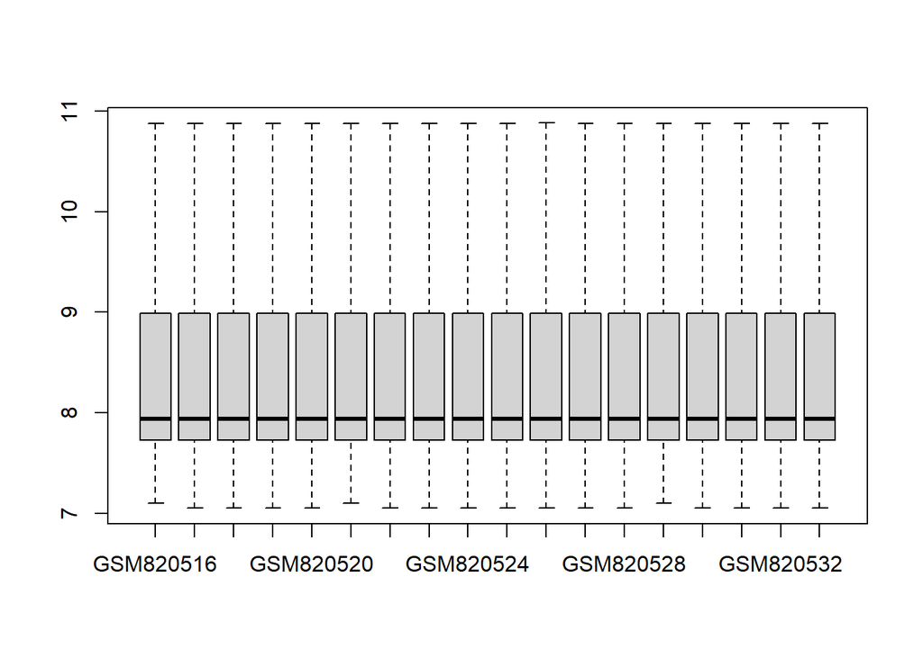

```r
#here we must transform the data to log2 scale
data.log <- log2(data)
boxplot(data.log, outline=FALSE)
```

## 1.2 Exporting the data

We can export the expression data to a csv/xls file for inspection in Excel using the `write.csv2` function.

```r
write.csv2(data, file="GSE33126_matrix.csv")
```

## 1.3 Accessing raw data from GEO

If raw data such as .CEL files exist on GEO, you can easily access this dea using the `getGEOSuppFiles()` function.

# 2 Querying for GDS, GSM or GPL classes

Each of these classes is comprised of a metadata header (taken nearly verbatim from the SOFT format header) and a GEODataTable. The GEODataTable has two simple parts, a Columns part which describes the column headers on the Table part. The following information can be accessed:

- Metadata: use `Meta()`
- Data table: use `Table()`
- Column descriptions: use `Columns()`

## 2.1 Example of querying a GEO Dataset

```r
# Download dataset
gds <- getGEO("GDS507")
```

```
## File stored at:
```

```
## e:\47865939H\AppData\Local\Temp\RtmpU9WPrR/GDS507.soft.gz
```

```r
# Look at metadata
gds_metadata <- Meta(gds)
# Get sample information
gds_tableinfo <- Columns(gds)
#Get the data table
gds_data <- Table(gds)
```

Note that the gds object from above can be converted to an ExpressionSet with function `GDS2eSet()`:

```r
eset_gds <- GDS2eSet(gds,do.log2=TRUE)
```

```
## File stored at:
```

```
## e:\47865939H\AppData\Local\Temp\RtmpU9WPrR/GPL97.annot.gz
```

```r
eset_gds
```

```
## ExpressionSet (storageMode: lockedEnvironment)
## assayData: 22645 features, 17 samples
##   element names: exprs
## protocolData: none
## phenoData
##   sampleNames: GSM11815 GSM11832 ... GSM12448 (17 total)
##   varLabels: sample disease.state individual description
##   varMetadata: labelDescription
## featureData
##   featureNames: 200000_s_at 200001_at ... AFFX-TrpnX-M_at (22645 total)
##   fvarLabels: ID Gene title ... GO:Component ID (21 total)
##   fvarMetadata: Column labelDescription
## experimentData: use 'experimentData(object)'
##   pubMedIds: 14641932
## Annotation:
```

## 2.2 Example of querying a GEO Sample

```r
gsm <- getGEO("GSM11805")
```

```
## File stored at:
```

```
## e:\47865939H\AppData\Local\Temp\RtmpU9WPrR/GSM11805.soft
```

```r
# Look at metadata
gsm_metadata <- Meta(gsm)
# Get sample information
gsm_tableinfo <- Columns(gsm)
#Get the data table
gsm_data <- Table(gsm)
```

## 2.3 Example of querying for a GEO Platform

```r
gpl <- getGEO("GPL6244")
```

```
## File stored at:
```

```
## e:\47865939H\AppData\Local\Temp\RtmpU9WPrR/GPL6244.soft
```

```r
# Look at metadata
gpl_metadata <- Meta(gpl)
# Get table information
gpl_tableinfo <- Columns(gpl)
#Get the data table
gpl_data <- Table(gpl)
```